# 我选择白葡萄酒数据做的探索性分析 by Rui Chen

```
## 'data.frame':    4898 obs. of  13 variables:
##  $ X                   : int  1 2 3 4 5 6 7 8 9 10 ...
##  $ fixed.acidity       : num  7 6.3 8.1 7.2 7.2 8.1 6.2 7 6.3 8.1 ...
##  $ volatile.acidity    : num  0.27 0.3 0.28 0.23 0.23 0.28 0.32 0.27 0.3 0.22 ...
##  $ citric.acid         : num  0.36 0.34 0.4 0.32 0.32 0.4 0.16 0.36 0.34 0.43 ...
##  $ residual.sugar      : num  20.7 1.6 6.9 8.5 8.5 6.9 7 20.7 1.6 1.5 ...
##  $ chlorides           : num  0.045 0.049 0.05 0.058 0.058 0.05 0.045 0.045 0.049 0.044 ...
##  $ free.sulfur.dioxide : num  45 14 30 47 47 30 30 45 14 28 ...
##  $ total.sulfur.dioxide: num  170 132 97 186 186 97 136 170 132 129 ...
##  $ density             : num  1.001 0.994 0.995 0.996 0.996 ...
##  $ pH                  : num  3 3.3 3.26 3.19 3.19 3.26 3.18 3 3.3 3.22 ...
##  $ sulphates           : num  0.45 0.49 0.44 0.4 0.4 0.44 0.47 0.45 0.49 0.45 ...
##  $ alcohol             : num  8.8 9.5 10.1 9.9 9.9 10.1 9.6 8.8 9.5 11 ...
##  $ quality             : int  6 6 6 6 6 6 6 6 6 6 ...
```

# 单变量绘图选择

白葡萄酒数据集包含4898个样本和13个变量，忽略其中的样本编号变量。以下为各变量，并对各变量做单变量EDA：

#### 变量

- fixed acidity/非挥发性酸度: g/dm^3
- volatile acidity/挥发性酸度: g/dm^3
- citric acid/柠檬酸: g/dm^3
- residual sugar/残留糖分: g/dm^3
- chlorides/盐分: g/dm^3
- free sulfur dioxide/游离二氧化硫: mg/dm^3
- total sulfur dioxide/总二氧化硫: mg/dm^3
- density/密度: g/dm^3
- pH/酸碱度
- sulphates/硫酸盐浓度: g/dm^3
- alcohol/酒精度: %
- quality/评分：0~10

#### EDA

1. fixed acidity/非挥发性酸度: g/dm^3

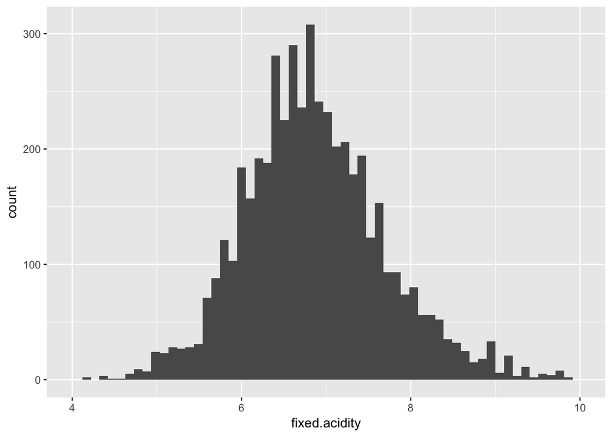

如图，大部分葡萄酒的非挥发性酸度在6-8之间，基本呈正态分布，统计值如下：

```
##    Min. 1st Qu.  Median    Mean 3rd Qu.    Max.
##   3.800   6.300   6.800   6.855   7.300  14.200
```

2. volatile acidity/挥发性酸度: g/dm^3

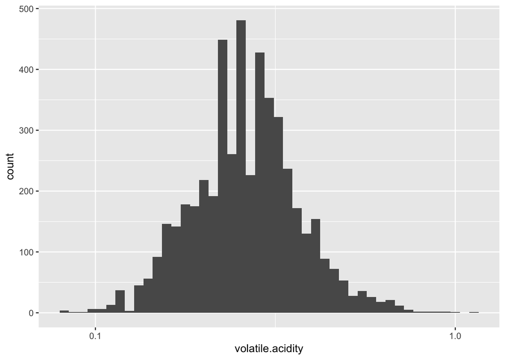

如图，变量也是大体在0.1-1.0间呈正态分布的。统计值如下：

```
##    Min. 1st Qu.  Median    Mean 3rd Qu.    Max.
##  0.0800  0.2100  0.2600  0.2782  0.3200  1.1000
```

3. citric acid/柠檬酸: g/dm^3

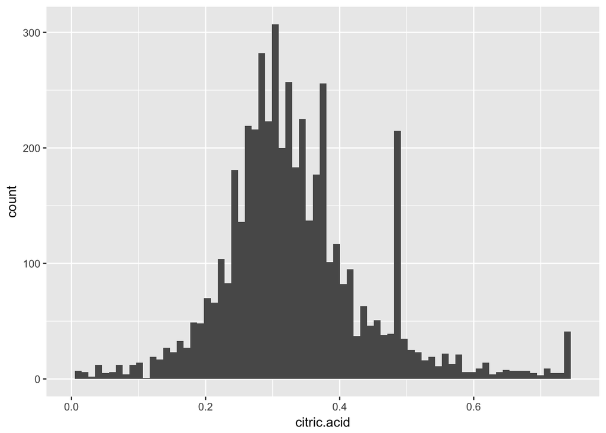

如图，大部分葡萄酒的柠檬酸在0.1-0.5g/dm^3之间，整体呈正态分布，但在0.5左右有一个高峰。这可能和葡萄酒的规格有关。统计值如下：

```
##    Min. 1st Qu.  Median    Mean 3rd Qu.    Max.
##  0.0000  0.2700  0.3200  0.3342  0.3900  1.6600
```

4. residual sugar/残留糖分: g/dm^3

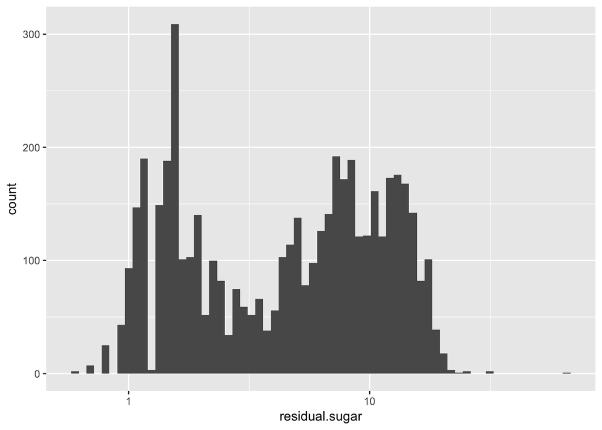

如图，变量呈双峰分布。统计值如下：

```
##    Min. 1st Qu.  Median    Mean 3rd Qu.    Max.
##   0.600   1.700   5.200   6.391   9.900  65.800
```

5. chlorides/盐分: g/dm^3

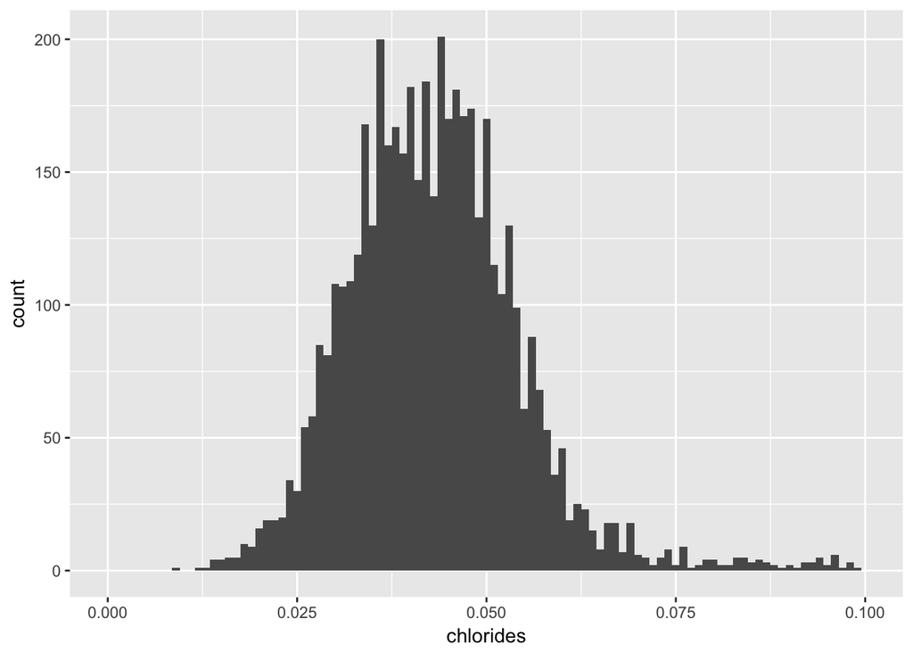

如图，大部分葡萄酒的盐分位于0.025-0.075g/dm^3的范围内，呈正态分布。统计值如下：

```
##    Min. 1st Qu.  Median    Mean 3rd Qu.    Max.
## 0.00900 0.03600 0.04300 0.04577 0.05000 0.34600
```

6. free sulfur dioxide/游离二氧化硫: mg/dm^3

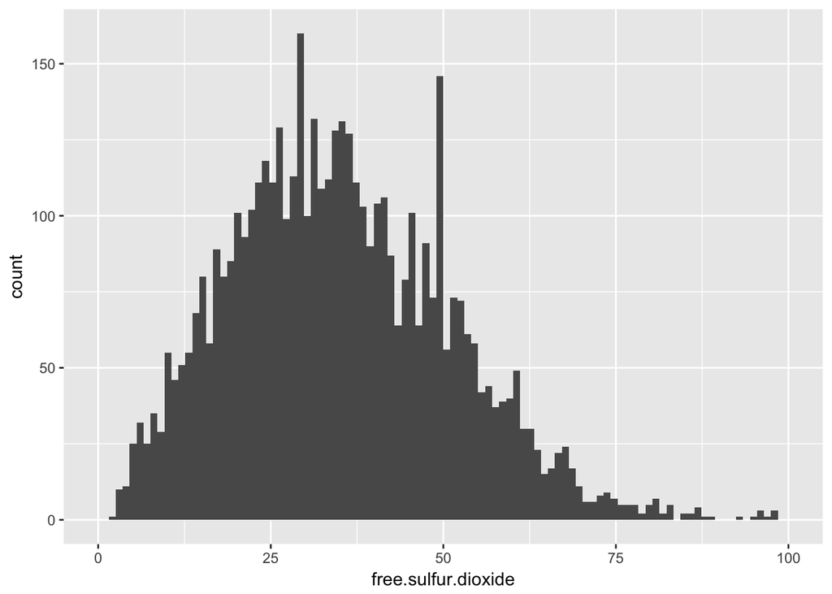

如图，大部分葡萄酒的游离二氧化硫含量在0-75mg/d^3的范围内，基本呈正态分布。统计值如下：

```
##    Min. 1st Qu.  Median    Mean 3rd Qu.    Max.
##    2.00   23.00   34.00   35.31   46.00  289.00
```

7. total sulfur dioxide/总二氧化硫: mg/dm^3

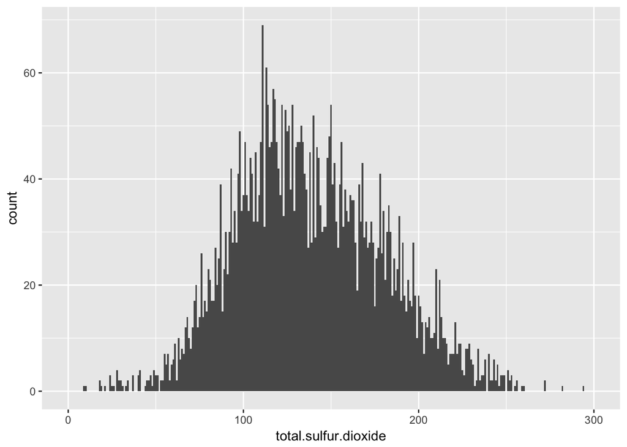

如图，大部分葡萄酒的总二氧化硫含量在50-250mg/d^3的范围内，基本呈正态分布。统计值如下：

```
##    Min. 1st Qu.  Median    Mean 3rd Qu.    Max.
##     9.0   108.0   134.0   138.4   167.0   440.0
```

8. density/密度: g/dm^3

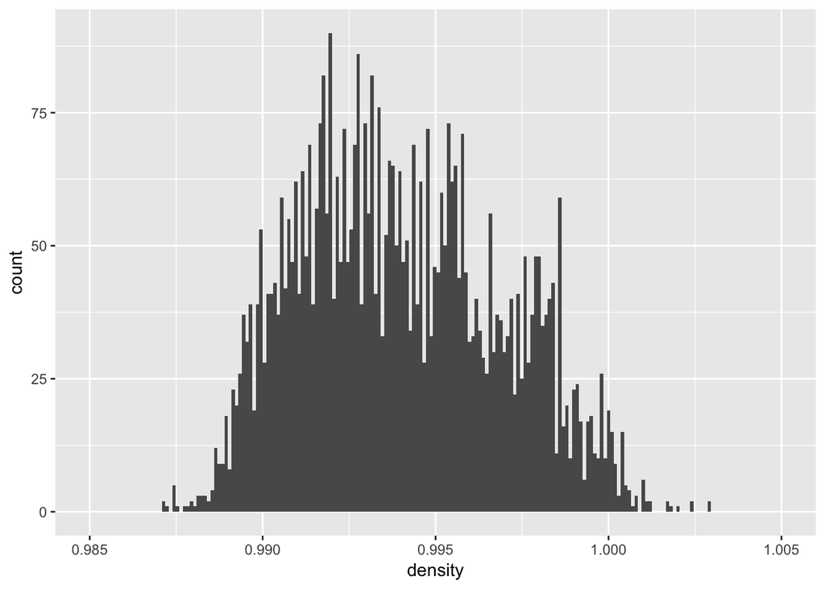

如图，大部分葡萄酒的密度在0.99-1g/d^3的范围内，基本呈正态分布，误差范围不大。统计值如下：

```
##    Min. 1st Qu.  Median    Mean 3rd Qu.    Max.
##  0.9871  0.9917  0.9937  0.9940  0.9961  1.0390
```

9. pH/酸碱度

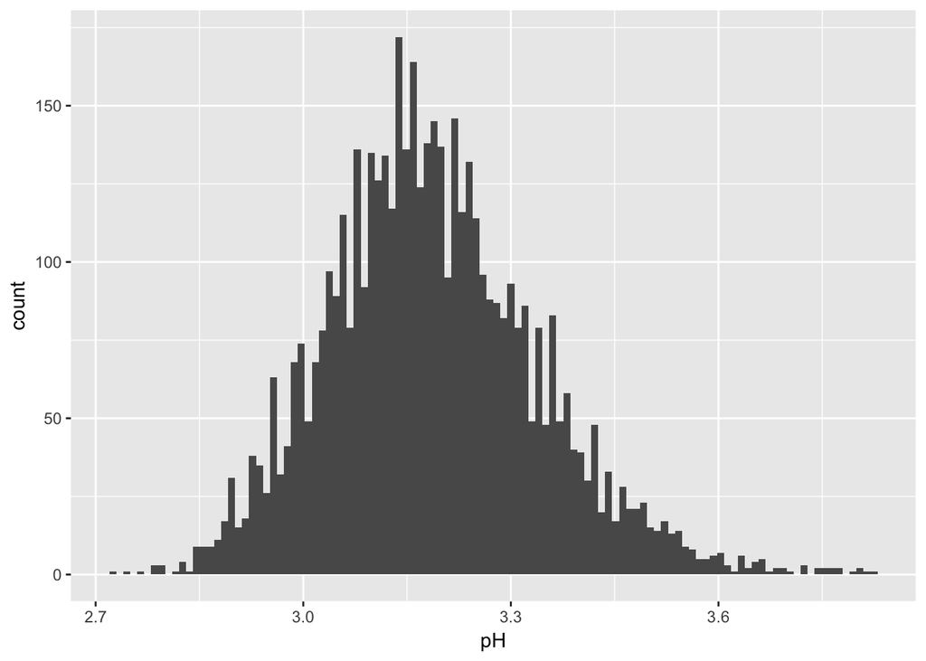

如图，大部分葡萄酒的酸碱度在2.7-3.6之间，基本呈正态分布。统计值如下：

```
##    Min. 1st Qu.  Median    Mean 3rd Qu.    Max.
##   2.720   3.090   3.180   3.188   3.280   3.820
```

10. sulphates/硫酸盐浓度: g/dm^3

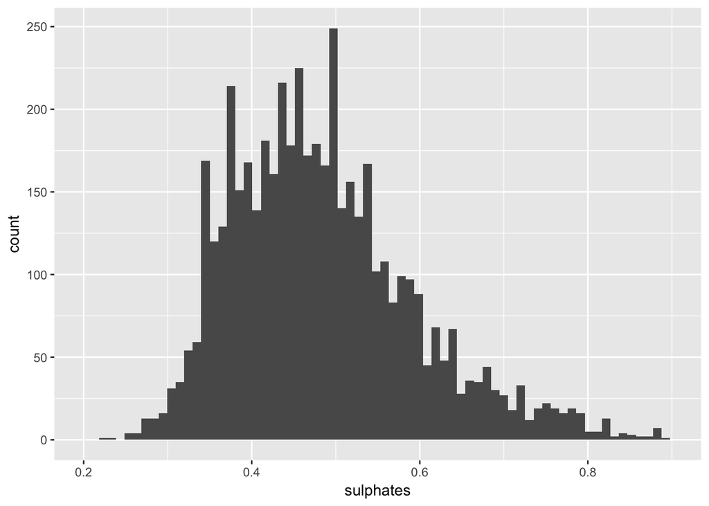

如图，大多数葡萄酒的硫酸盐浓度在0.3-0.7g/dm^3范围内，基本呈正态分布。统计值如下：

```
##    Min. 1st Qu.  Median    Mean 3rd Qu.    Max.
##  0.2200  0.4100  0.4700  0.4898  0.5500  1.0800
```

11. alcohol/酒精度: %

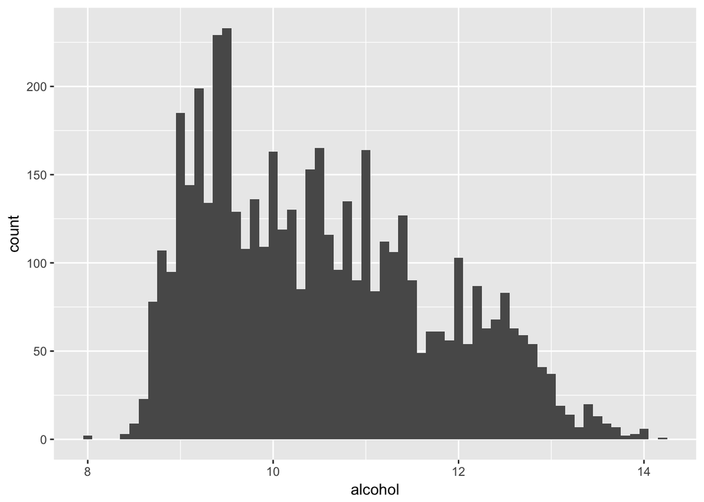

如图，酒精度变量呈长尾分布，统计值如下：

```
##    Min. 1st Qu.  Median    Mean 3rd Qu.    Max.
##    8.00    9.50   10.40   10.51   11.40   14.20
```

12. quality/品质：0~10

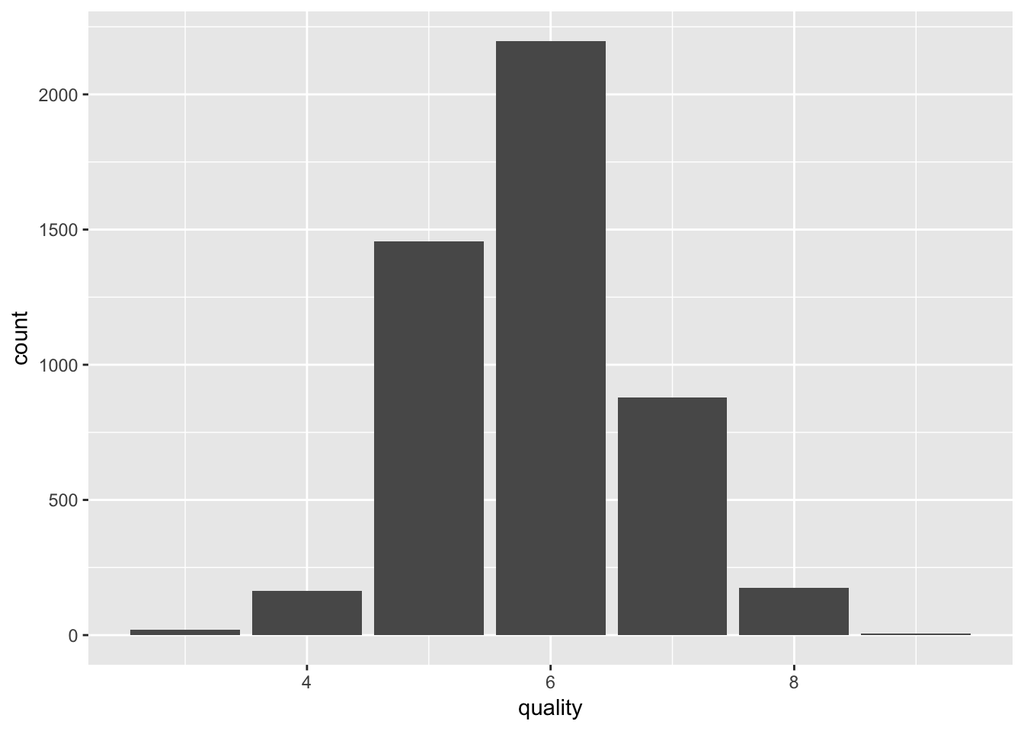

如图，葡萄酒的品质均在3-9之间。

# 单变量分析

### 你的数据集结构是什么？

本数据集有4898个种类的葡萄酒样本，13个变量。大部分葡萄酒的品质范围在5-7之间，葡萄酒的密度差异不大。

### 你的数据集内感兴趣的主要特性有哪些？

葡萄酒的品质。探索其他变量和葡萄酒品质的关系，得出一系列统计推论。

### 你认为数据集内哪些其他特征可以帮助你探索兴趣特点？

除品质和序号外的其他11个变量都有助于对葡萄酒品质的分析。

### 根据数据集内已有变量，你是否创建了任何新变量？

没有。

### 在已经探究的特性中，是否存在任何异常分布？你是否对数据进行一些操作，如清洁、调整或改变数据的形式？如果是，你为什么会这样做？

volatile acidity/挥发性酸度: g/dm^3 residual sugar/残留糖分: g/dm^3 sulphates/硫酸盐浓度: g/dm^3

fixed acidity/非挥发性酸度: g/dm^3 citric acid/柠檬酸: g/dm^3 residual sugar/残留糖分: g/dm^3 chlorides/盐分: g/dm^3 free sulfur dioxide/游离二氧化硫: mg/dm^3 total sulfur dioxide/总二氧化硫: mg/dm^3 sulphates/硫酸盐浓度: g/dm^3

上面几个变量存在较大/小的异常值，我通过限制范围获得合理的分布直方图。

# 双变量绘图选择

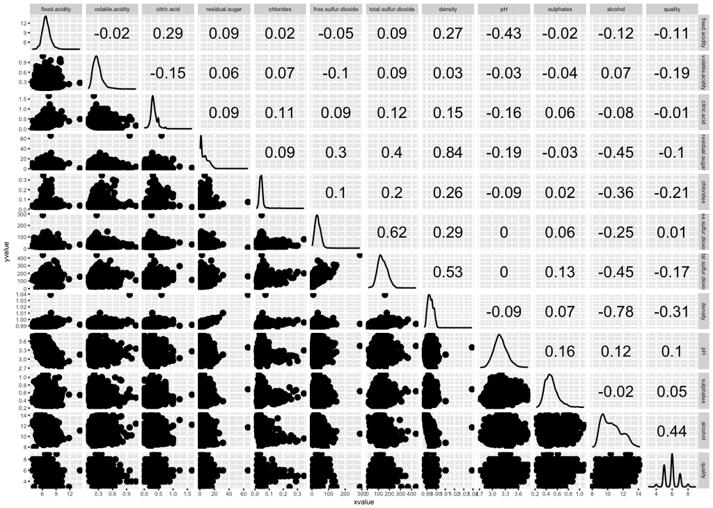

如图，盐分、密度、酒精度和葡萄酒品质有相关性，所以选择研究这三个变量。

从盐分、密度和酒精度三个变量对葡萄酒品质变量依次做探索性分析。

葡萄酒品质作为因子变量，箱线图分析：

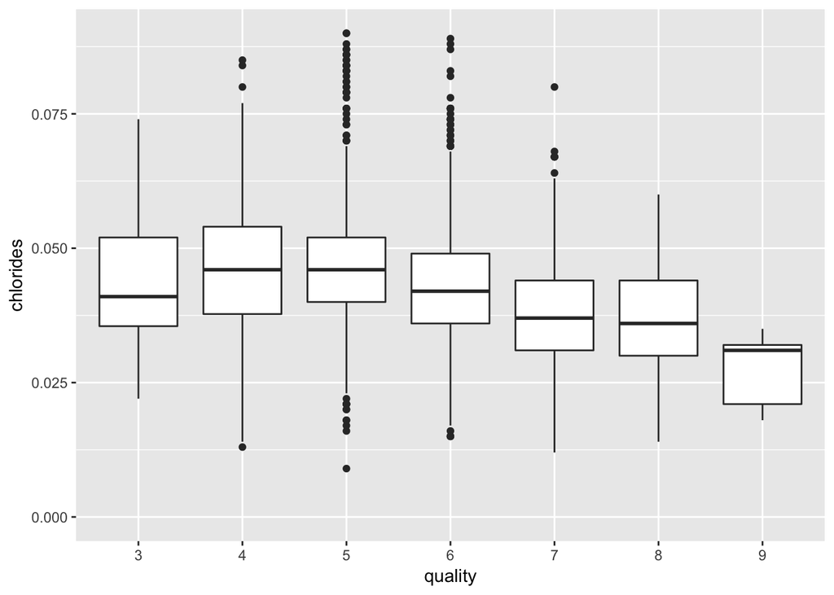

由箱线图可以看出，品质较高的白葡萄酒盐度总体较低。统计值如下：

```
## wine$quality: 3
##    Min. 1st Qu.  Median    Mean 3rd Qu.    Max.
## 0.02200 0.03625 0.04100 0.05430 0.05400 0.24400
## --------------------------------------------------------
## wine$quality: 4
##    Min. 1st Qu.  Median    Mean 3rd Qu.    Max.
##  0.0130  0.0380  0.0460  0.0501  0.0540  0.2900
## --------------------------------------------------------
## wine$quality: 5
##    Min. 1st Qu.  Median    Mean 3rd Qu.    Max.
## 0.00900 0.04000 0.04700 0.05155 0.05300 0.34600
## --------------------------------------------------------
## wine$quality: 6
##    Min. 1st Qu.  Median    Mean 3rd Qu.    Max.
## 0.01500 0.03600 0.04300 0.04522 0.04900 0.25500
## --------------------------------------------------------
## wine$quality: 7
##    Min. 1st Qu.  Median    Mean 3rd Qu.    Max.
## 0.01200 0.03100 0.03700 0.03819 0.04400 0.13500
## --------------------------------------------------------
## wine$quality: 8
##    Min. 1st Qu.  Median    Mean 3rd Qu.    Max.
## 0.01400 0.03000 0.03600 0.03831 0.04400 0.12100
## --------------------------------------------------------
## wine$quality: 9
##    Min. 1st Qu.  Median    Mean 3rd Qu.    Max.
##  0.0180  0.0210  0.0310  0.0274  0.0320  0.0350
```

密度和葡萄酒品质作箱线图分析：

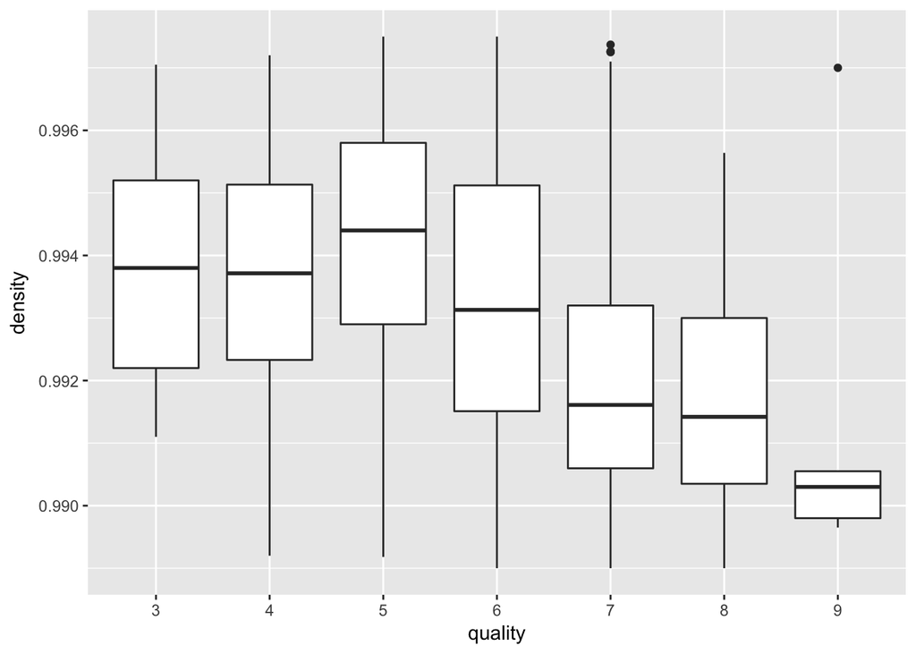

品质更高的葡萄酒密度会偏低。统计值如下：

```
## wine$quality: 3
##    Min. 1st Qu.  Median    Mean 3rd Qu.    Max.
##  0.9911  0.9925  0.9944  0.9949  0.9969  1.0001
## --------------------------------------------------------
## wine$quality: 4
##    Min. 1st Qu.  Median    Mean 3rd Qu.    Max.
##  0.9892  0.9926  0.9941  0.9943  0.9958  1.0004
## --------------------------------------------------------
## wine$quality: 5
##    Min. 1st Qu.  Median    Mean 3rd Qu.    Max.
##  0.9872  0.9933  0.9953  0.9953  0.9972  1.0024
## --------------------------------------------------------
## wine$quality: 6
##    Min. 1st Qu.  Median    Mean 3rd Qu.    Max.
##  0.9876  0.9917  0.9937  0.9940  0.9959  1.0390
## --------------------------------------------------------
## wine$quality: 7
##    Min. 1st Qu.  Median    Mean 3rd Qu.    Max.
##  0.9871  0.9906  0.9918  0.9925  0.9937  1.0004
## --------------------------------------------------------
## wine$quality: 8
##    Min. 1st Qu.  Median    Mean 3rd Qu.    Max.
##  0.9871  0.9903  0.9916  0.9922  0.9935  1.0006
## --------------------------------------------------------
## wine$quality: 9
##    Min. 1st Qu.  Median    Mean 3rd Qu.    Max.
##  0.9897  0.9898  0.9903  0.9915  0.9906  0.9970
```

对酒精度和葡萄酒作箱线图分析：

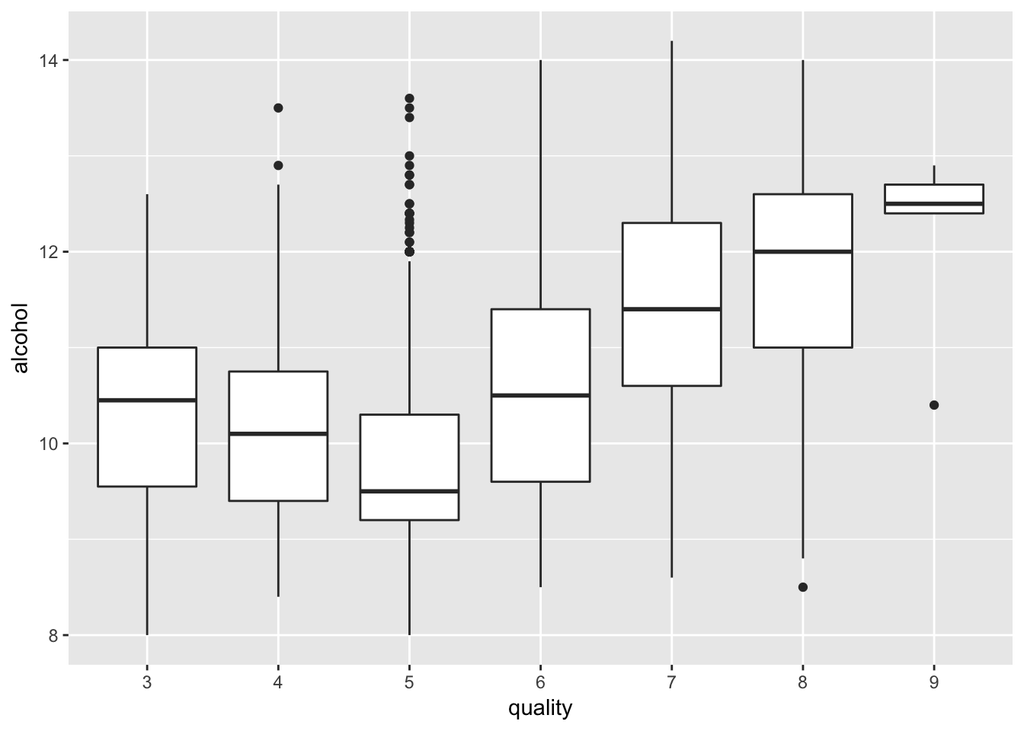

如图，品质好的葡萄酒酒精度大体也会偏高，统计值如下：

```
## wine$quality: 3
##    Min. 1st Qu.  Median    Mean 3rd Qu.    Max.
##    8.00    9.55   10.45   10.35   11.00   12.60
## --------------------------------------------------------
## wine$quality: 4
##    Min. 1st Qu.  Median    Mean 3rd Qu.    Max.
##    8.40    9.40   10.10   10.15   10.75   13.50
## --------------------------------------------------------
## wine$quality: 5
##    Min. 1st Qu.  Median    Mean 3rd Qu.    Max.
##   8.000   9.200   9.500   9.809  10.300  13.600
## --------------------------------------------------------
## wine$quality: 6
##    Min. 1st Qu.  Median    Mean 3rd Qu.    Max.
##    8.50    9.60   10.50   10.58   11.40   14.00
## --------------------------------------------------------
## wine$quality: 7
##    Min. 1st Qu.  Median    Mean 3rd Qu.    Max.
##    8.60   10.60   11.40   11.37   12.30   14.20
## --------------------------------------------------------
## wine$quality: 8
##    Min. 1st Qu.  Median    Mean 3rd Qu.    Max.
##    8.50   11.00   12.00   11.64   12.60   14.00
## --------------------------------------------------------
## wine$quality: 9
##    Min. 1st Qu.  Median    Mean 3rd Qu.    Max.
##   10.40   12.40   12.50   12.18   12.70   12.90
```

# 双变量分析

### 探讨你在这部分探究中观察到的一些关系。这些感兴趣的特性与数据集内其他特性有什么区别？

葡萄酒的品质和盐度、酒精度和密度相关程度较高，与其他变量相关程度较低； 品质越好的葡萄酒总体而言盐度和密度会更低，酒精度会更高。

### 你是否观察到主要特性与其他特性之间的有趣关系？

酒精度和密度相关程度高，在于这两个变量不相互独立的，一方变化会导致另一方的变化。

# 多变量绘图选择

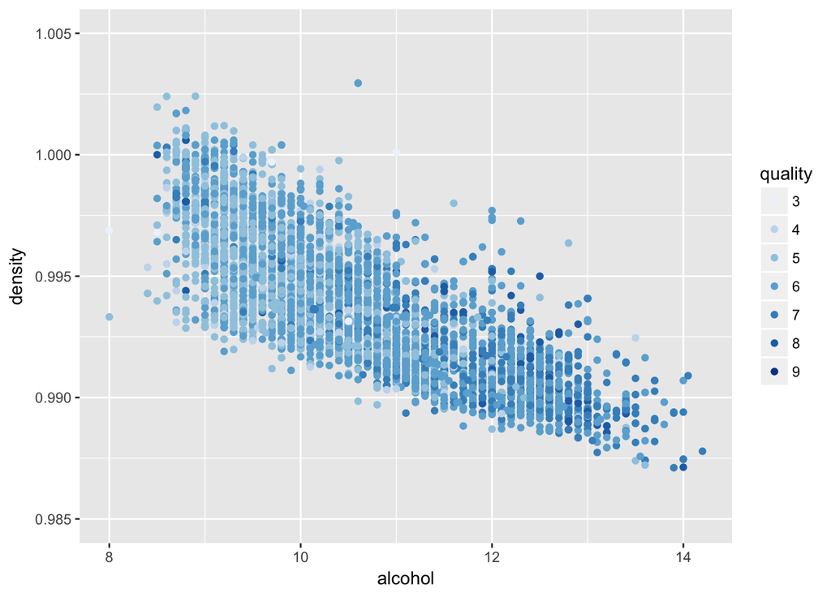

如图，品质较好的葡萄酒在散点图右下方聚集，葡萄酒的品质和密度及酒精度的相关性较强。

加入盐度变量：

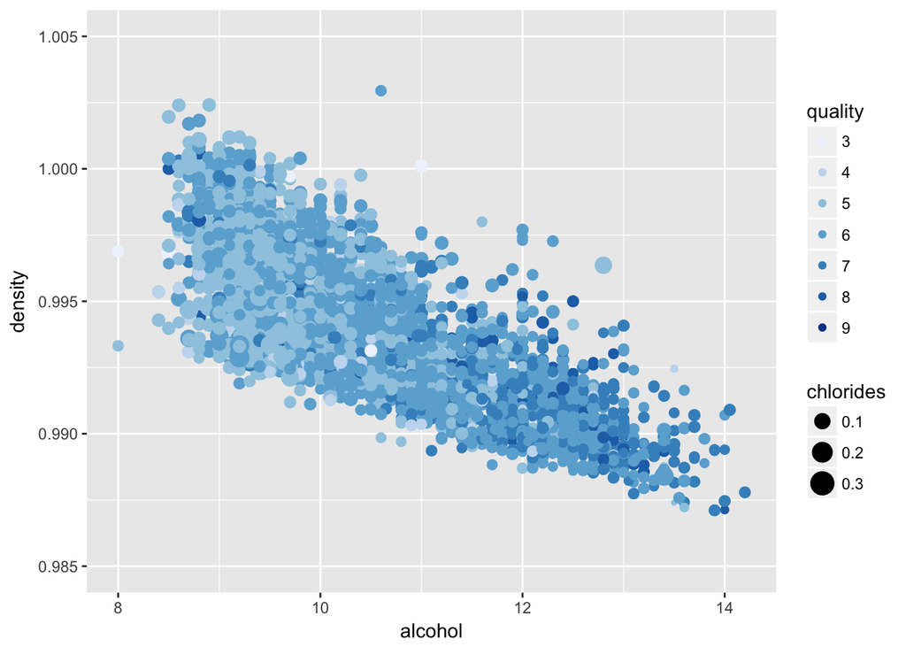

如图，品质较高的葡萄酒，盐度相对偏小。

建立线性回归模型：

```
##
## Calls:
## m1: lm(formula = I(quality) ~ alcohol + chlorides, data = wine)
## m2: lm(formula = I(quality) ~ alcohol + chlorides + fixed.acidity +
##     log(volatile.acidity) + citric.acid + log(residual.sugar) +
##     free.sulfur.dioxide + total.sulfur.dioxide + pH + sulphates,
##     data = wine)
##
## =====================================================
##                               m1            m2
## -----------------------------------------------------
##   (Intercept)                2.861***      0.781*
##                             (0.116)       (0.347)
##   alcohol                    0.298***      0.361***
##                             (0.010)       (0.011)
##   chlorides                 -2.471***     -0.984
##                             (0.558)       (0.539)
##   fixed.acidity                           -0.055***
##                                           (0.015)
##   log(volatile.acidity)                   -0.615***
##                                           (0.034)
##   citric.acid                              0.016
##                                           (0.095)
##   log(residual.sugar)                      0.155***
##                                           (0.014)
##   free.sulfur.dioxide                      0.005***
##                                           (0.001)
##   total.sulfur.dioxide                    -0.001*
##                                           (0.000)
##   pH                                       0.130
##                                           (0.082)
##   sulphates                                0.417***
##                                           (0.097)
## -----------------------------------------------------
##   R-squared                  0.193         0.278
##   adj. R-squared             0.193         0.277
##   sigma                      0.796         0.753
##   F                        585.182       188.484
##   p                          0.000         0.000
##   Log-likelihood         -5829.599     -5555.767
##   Deviance                3099.838      2771.908
##   AIC                    11667.199     11135.535
##   BIC                    11693.185     11213.494
##   N                       4898          4898
## =====================================================
```

如上，酒精度和盐度可以解释20%的葡萄酒品质，而加上其他的变量也仅能30%。

# 多变量分析

### 探讨你在这部分探究中观察到的一些关系。通过观察感兴趣的特性，是否存在相互促进的特性？

变量间的关系： 品质好的葡萄酒密度更低，酒精度更高，盐度也更低。在多变量相关分析时更明显。

### 这些特性之间是否存在有趣或惊人的联系呢？

没有

### 选项：你是否创建过数据集的任何模型？讨论你模型的优缺点。

建立了线性回归模型，但该模型的拟合效果并不好。可能与因变量为因子变量或者自变量数据处理得不够充分有关。但该模型的相关系数依然有30%，有一定的解释力。

# 定稿图与总结

### 绘图一

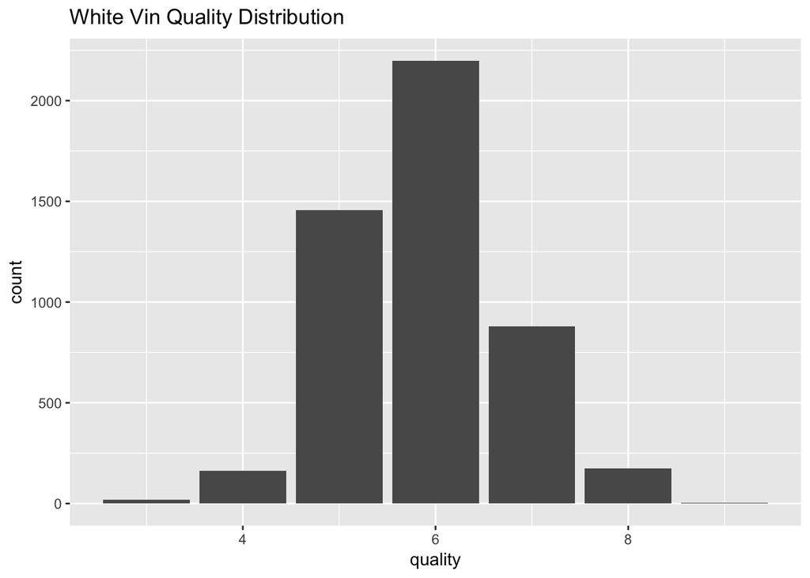

### 描述一

上图显示了葡萄酒的评分分布。评分范围为0-10，大部分都在5-7之间，形成明显的集中趋势。

### 绘图二

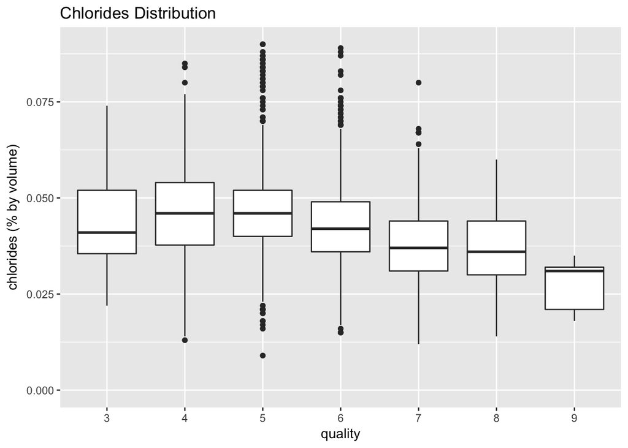

### 绘图三

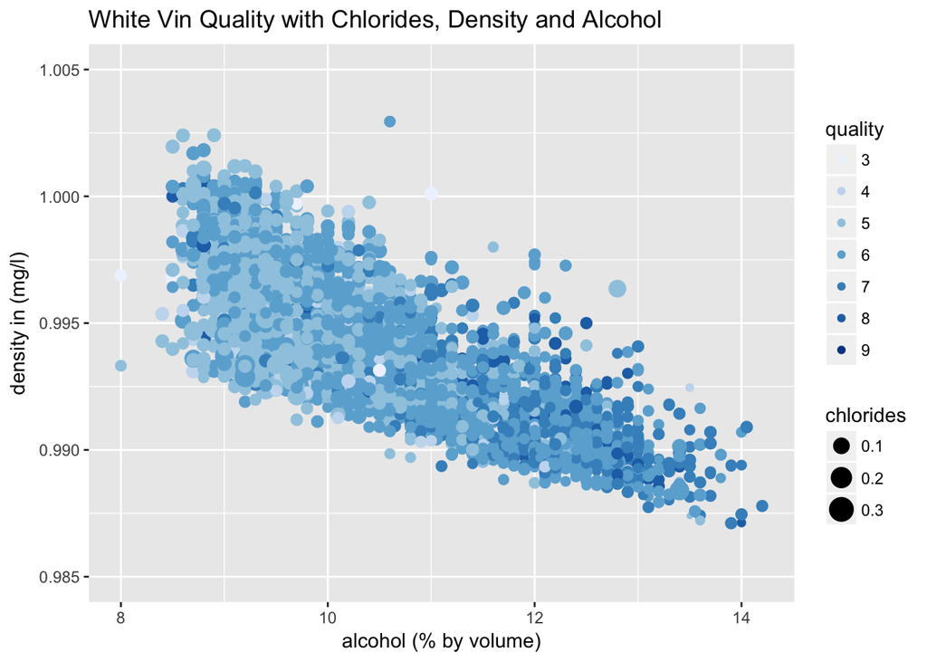

### 描述三

上图探索了盐度、密度、酒精度和葡萄酒品质4个变量的关系。品质为5的葡萄酒大部分集中于左上方，点较大，品质为7的葡萄酒则集中于右下方，点较小。葡萄酒品质的影响因素：盐度越低、酒精度越高、密度越小，则品质越好。

# 反思

这个白葡萄酒数据数据集的探索分析只是研究影响白葡萄酒品质的因素，就是各变量和酒品质的关系。虽然有明确目的，但也比较局限，并没有做其它分析。

通过对单变量、双变量和多变量分析，确定了与葡萄酒品质相关性较强的三个因素即酒精度、密度和盐度，与其他变量的相关性则较小。

通过绘制图表，进行描述性统计量的计算，并建立线性回归模型，初步分析了影响葡萄酒质量的各个因素。但该模型的拟合效果并不好，方法可能并不科学，分析效果有限。

通过以后机器学习的提高，也许会建立更好的分析模型。